# Notebook 14

## Getting Started

Before running this notebook, select “Session > Restart R and Clear Output” in the menu above to start a new R session. This will clear any old data sets and give us a blank slate to start with.

## What We Eat in America

Today we will continue to look at the *What We Eat in America* dataset. We can read the tables in with the following:

```r
food <- read_csv("../data/wweia_food.csv.bz2")
demo <- read_csv("../data/wweia_demo.csv.bz2")
meta <- read_csv("../data/wweia_meta.csv.bz2")
```

We will try to apply some of the modeling techniques from the notes as we study more about this data.

### Modelling Alcohol and Age

The data contains information about how much alcohol was in a particular food item. Create a plot that shows the average amount of alcohol that people of a particular age consume within the data. Use the actual ages, not the buckets that we created in the previous notebook.

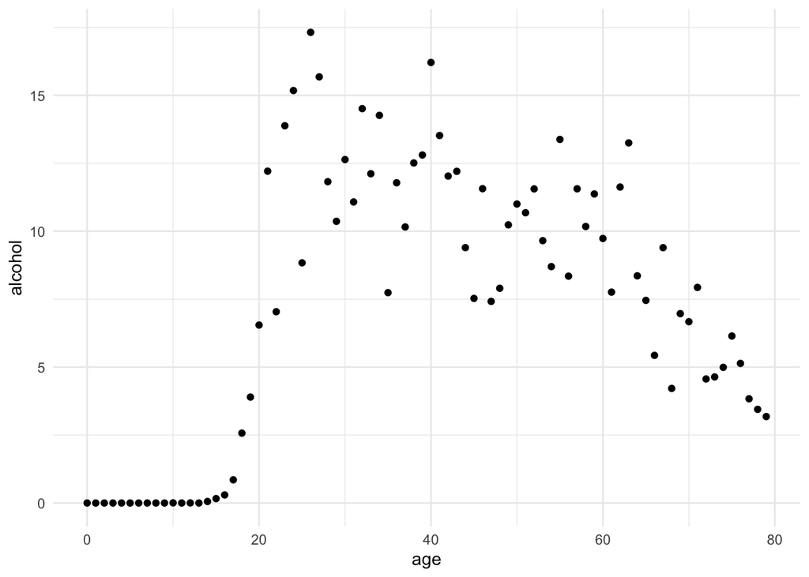

```r
# Question 01
food |>
  group_by(id) |>
  summarize(alcohol = sum(alcohol)) |>
  inner_join(demo, by = "id") |>
  group_by(age) |>
  summarize(alcohol = mean(alcohol)) |>
  ggplot(aes(age, alcohol)) +
    geom_point()
```

You should see that there is a strong relationship between age and alcohol consumption. Let’s try to model this relationship. Below, create a new dataset called `temp` that gives the average daily alcohol consumption by age. Filter to only include those ages equal or greater than 21 years.

```r
# Question 02
temp <- food |>
  group_by(id) |>
  summarize(alcohol = sum(alcohol)) |>
  inner_join(demo, by = "id") |>
  filter(age >= 21) |>
  group_by(age) |>
  summarize(alcohol = mean(alcohol))
temp
```

```
## # A tibble: 59 × 2
##      age alcohol
##    <dbl>   <dbl>
##  1    21   12.2
##  2    22    7.04
##  3    23   13.9
##  4    24   15.2
##  5    25    8.84
##  6    26   17.3
##  7    27   15.7
##  8    28   11.8
##  9    29   10.4
## 10    30   12.6
## # ℹ 49 more rows
```

Build and save a linear regression model below that predicts alcohol usage based on age using the data you just created. Print out the output of the `tidy` function applied to the data and try to understand what the numbers in the output mean.

```r
# Question 03
model <- lm(alcohol ~ age, data = temp)
tidy(model)
```

```
## # A tibble: 2 × 5
##   term        estimate std.error statistic  p.value
##   <chr>          <dbl>     <dbl>     <dbl>    <dbl>
## 1 (Intercept)   17.0      0.969      17.5  1.20e-24
## 2 age           -0.143    0.0183     -7.80 1.48e-10
```

Now, reproduce the plot from question one for the ages greater than 21 but add a linear regression line using the `augment` function. Does the fit seem as you would expect?

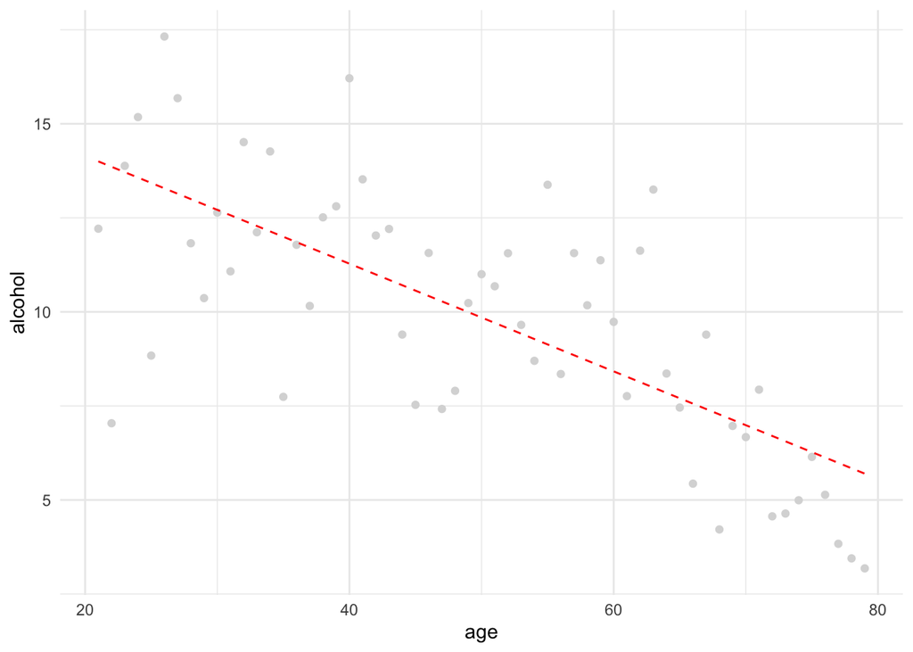

```r
# Question 04
model |>
  augment(newdata = temp) |>
  ggplot(aes(age, alcohol)) +
    geom_point(color = "grey85") +
    geom_line(aes(y = .fitted), color = "red", linetype ="dashed")
```

Does alcohol consumption differ by gender across ages? Let’s create a dataset named `temp` again, but summarize the data by age and gender. Produce a model that incorporates different slopes and intercepts for male and female groups by using the formula `alcohol ~ age * gender`. Print out the output of the `tidy` function applied to the model.

```r
# Question 05
temp <- food |>
  group_by(id) |>
  summarize(alcohol = sum(alcohol)) |>
  inner_join(demo, by = "id") |>
  filter(age >= 21) |>
  group_by(age, gender) |>
  summarize(alcohol = mean(alcohol))
model <- lm(alcohol ~ age * gender, data = temp)
tidy(model)
```

```
## # A tibble: 4 × 5
##   term           estimate std.error statistic  p.value
##   <chr>             <dbl>     <dbl>     <dbl>    <dbl>
## 1 (Intercept)      9.94      1.40        7.08 1.28e-10
## 2 age             -0.0875    0.0266     -3.29 1.34e- 3
## 3 genderMale      15.3       1.99        7.71 5.04e-12
## 4 age:genderMale  -0.129     0.0376     -3.42 8.76e- 4
```

In the code block below, plot the model with `augment`. Be careful here! You’ll need to use the color aesthetic to get this to look correct.

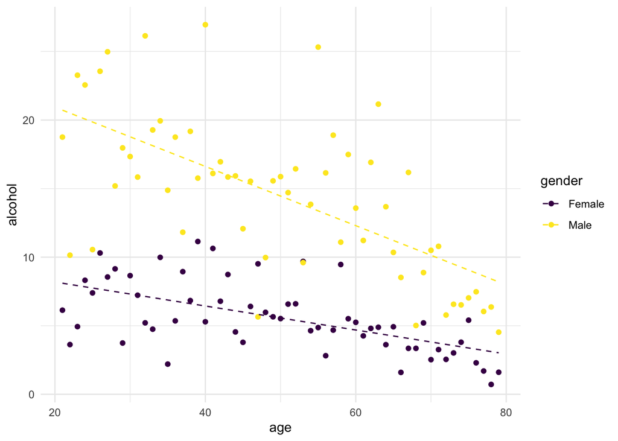

```r
# Question 06
model |>
  augment(newdata = temp) |>
  ggplot(aes(age, alcohol)) +
    geom_point(aes(color = gender)) +
    geom_line(aes(y = .fitted, color = gender), linetype ="dashed") +
    scale_color_viridis_d()
```

There’s a shortcut to making the plot above. We can add the following layer onto a plot:

- `geom_smooth(aes(color = gender), method = "lm", se = FALSE, formula = y ~ x)`

To automatically fit a linear regression for each gender. Using the `temp` dataset, plot the points and the output of the `geom_smooth` layer given above. Verify that this looks the same as the plot you made in the prior question.

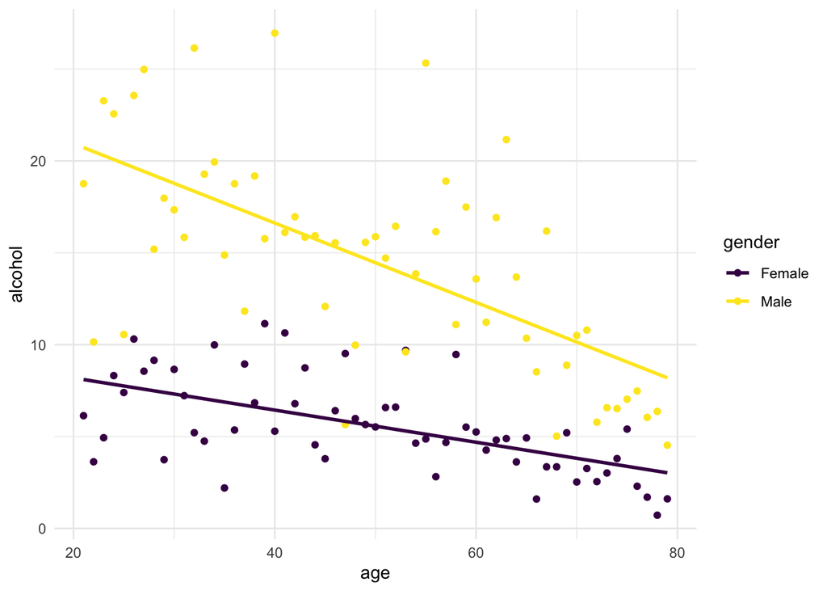

```r
# Question 07
temp |>
  ggplot(aes(age, alcohol)) +
    geom_point(aes(color = gender)) +
    geom_smooth(aes(color = gender), method = "lm", se = FALSE, formula = y ~ x) +
    scale_color_viridis_d()
```

While ggplot gives us the ability to create this plot quickly, it is not easy to get access to the other model metrics that our more involved approach in the previous questions gave us.

### Caffeine

Let’s move on to caffeine. Produce a similar plot to the one in question 7 for caffeine consumption by gender and age. This time, though, use the following `geom_smooth` instead:

- `geom_smooth(aes(color = gender), method = "loess", se = FALSE, formula = y ~ x)`

This will fit a curve rather than a straight line. You’ll see in the plot why this is needed.

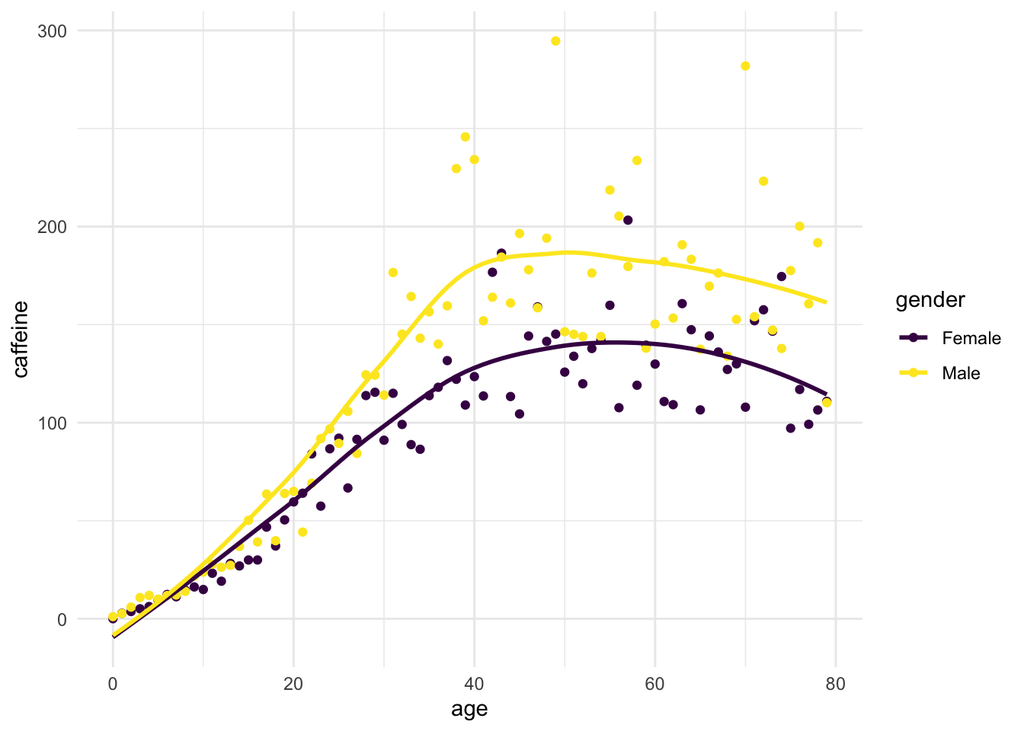

```r
# Question 08
food |>
  group_by(id) |>
  summarize(caffeine = sum(caffeine)) |>
  inner_join(demo, by = "id") |>
  group_by(age, gender) |>
  summarize(caffeine = mean(caffeine)) |>
  ggplot(aes(age, caffeine)) +
    geom_point(aes(color = gender)) +
    geom_smooth(aes(color = gender), method = "loess", se = FALSE, formula = y ~ x) +
    scale_color_viridis_d()
```

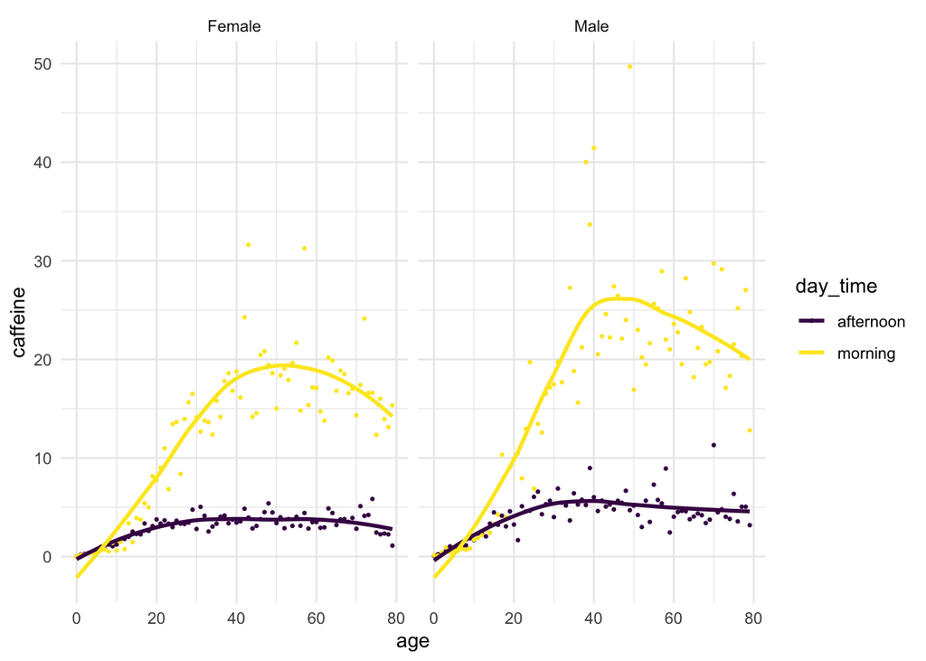

```r
# Question 09
food |>
  mutate(day_time = if_else(time < 12, "morning", "afternoon")) |>
  inner_join(demo, by = "id") |>
  group_by(age, gender, day_time) |>
  summarize(caffeine = mean(caffeine)) |>
  ggplot(aes(age, caffeine)) +
    geom_point(aes(color = day_time), size = 0.5) +
    geom_smooth(aes(color = day_time), method = "loess", se = FALSE, formula = y ~ x) +
    facet_wrap(~gender) +
    scale_color_viridis_d()
```

### Model Metrics

Let’s create a linear model corresponding to the one you just produce in Q9, but this time do it by creating a temporary data table and the `lm` function. The formula should be `gender + age + day_time` (if you called the time of day variable you made `day_time`).

```r
# Question 10
temp <- food |>
  mutate(day_time = if_else(time < 12, "morning", "afternoon")) |>
  inner_join(demo, by = "id") |>
  group_by(age, gender, day_time) |>
  summarize(caffeine = mean(caffeine))
model <- lm(caffeine ~ gender + age + day_time, data = temp)
tidy(model)
```

```
## # A tibble: 4 × 5
##   term            estimate std.error statistic  p.value
##   <chr>              <dbl>     <dbl>     <dbl>    <dbl>
## 1 (Intercept)       -4.06     0.753      -5.40 1.31e- 7
## 2 genderMale         2.65     0.618       4.29 2.39e- 5
## 3 age                0.162    0.0134     12.1  5.86e-28
## 4 day_timemorning   11.2      0.618      18.2  6.15e-51
```

Use the function `glance` to see the model statistics:

```r
# Question 11
glance(model)
```

```
## # A tibble: 1 × 12
##   r.squared adj.r.squared sigma statistic  p.value    df logLik   AIC   BIC
##       <dbl>         <dbl> <dbl>     <dbl>    <dbl> <dbl>  <dbl> <dbl> <dbl>
## 1     0.610         0.606  5.53      165. 2.70e-64     3  -999. 2009. 2028.
## # ℹ 3 more variables: deviance <dbl>, df.residual <int>, nobs <int>
```

The value `r.squared` tells us the proportion of the variation in the data explained by the model (it ranges from 0 to 1). How much of the variation in the data are described by model you built? Does that make sense to you based on the plot?

**Answer**: quite a lot for this kind of data. This makes sense from the plot because we see that these three variables do have a large effect on caffeine usage but that the relationship is not perfectly linear and there is still quite a lot of noise in the data.